# 18110213_DaoNgocPhuongThanh_ DM Lab07

```python
# Data Manipulation
import numpy as np
import pandas as pd
import math
# Visualization
import matplotlib.pyplot as plt
import missingno
import seaborn as sns
from pandas.plotting import scatter_matrix

# Feature Selection and Encoding
from sklearn.feature_selection import RFE, RFECV
from sklearn.svm import SVR
from sklearn.decomposition import PCA
from sklearn.preprocessing import OneHotEncoder, LabelEncoder, label_binarize

# Machine learning
import sklearn.ensemble as ske
from sklearn import datasets, model_selection, tree, preprocessing, metrics, linear_model
from sklearn.svm import LinearSVC
from sklearn.ensemble import RandomForestClassifier, GradientBoostingClassifier
from sklearn.neighbors import KNeighborsClassifier
from sklearn.naive_bayes import GaussianNB
from sklearn.linear_model import LinearRegression, LogisticRegression, Ridge, Lasso, SGDClassifier
from sklearn.tree import DecisionTreeClassifier
import tensorflow as tf

# Grid and Random Search
import scipy.stats as st
from scipy.stats import randint as sp_randint
from sklearn.model_selection import GridSearchCV
from sklearn.model_selection import RandomizedSearchCV

# Metrics
from sklearn.metrics import precision_recall_fscore_support, roc_curve, auc

# Managing Warnings
import warnings
warnings.filterwarnings('ignore')

# Plot the Figures Inline
%matplotlib inline
```

```python
data=pd.read_csv(r"C:\Users\Thanh\Documents\Data mining\Data_Mining_Lab07\bank-full.csv")
data.head()
```

|  | age | job | marital | education | default | balance | housing | loan | contact | day | month | duration | campaign | pdays | previous | poutcome | Target |
| --- | --- | --- | --- | --- | --- | --- | --- | --- | --- | --- | --- | --- | --- | --- | --- | --- | --- |
| 0 | 58 | management | married | tertiary | no | 2143 | yes | no | unknown | 5 | may | 261 | 1 | -1 | 0 | unknown | no |
| 1 | 44 | technician | single | secondary | no | 29 | yes | no | unknown | 5 | may | 151 | 1 | -1 | 0 | unknown | no |
| 2 | 33 | entrepreneur | married | secondary | no | 2 | yes | yes | unknown | 5 | may | 76 | 1 | -1 | 0 | unknown | no |
| 3 | 47 | blue-collar | married | unknown | no | 1506 | yes | no | unknown | 5 | may | 92 | 1 | -1 | 0 | unknown | no |
| 4 | 33 | unknown | single | unknown | no | 1 | no | no | unknown | 5 | may | 198 | 1 | -1 | 0 | unknown | no |

```python
data.info()
```

```
<class 'pandas.core.frame.DataFrame'>
RangeIndex: 45211 entries, 0 to 45210
Data columns (total 17 columns):
 #   Column     Non-Null Count  Dtype
---  ------     --------------  -----
 0   age        45211 non-null  int64
 1   job        45211 non-null  object
 2   marital    45211 non-null  object
 3   education  45211 non-null  object
 4   default    45211 non-null  object
 5   balance    45211 non-null  int64
 6   housing    45211 non-null  object
 7   loan       45211 non-null  object
 8   contact    45211 non-null  object
 9   day        45211 non-null  int64
 10  month      45211 non-null  object
 11  duration   45211 non-null  int64
 12  campaign   45211 non-null  int64
 13  pdays      45211 non-null  int64
 14  previous   45211 non-null  int64
 15  poutcome   45211 non-null  object
 16  Target     45211 non-null  object
dtypes: int64(7), object(10)
memory usage: 5.9+ MB
```

There are not missing values

```python
data.describe()
```

|  | age | balance | day | duration | campaign | pdays | previous |
| --- | --- | --- | --- | --- | --- | --- | --- |
| count | 45211.000000 | 45211.000000 | 45211.000000 | 45211.000000 | 45211.000000 | 45211.000000 | 45211.000000 |
| mean | 40.936210 | 1362.272058 | 15.806419 | 258.163080 | 2.763841 | 40.197828 | 0.580323 |
| std | 10.618762 | 3044.765829 | 8.322476 | 257.527812 | 3.098021 | 100.128746 | 2.303441 |
| min | 18.000000 | -8019.000000 | 1.000000 | 0.000000 | 1.000000 | -1.000000 | 0.000000 |
| 25% | 33.000000 | 72.000000 | 8.000000 | 103.000000 | 1.000000 | -1.000000 | 0.000000 |
| 50% | 39.000000 | 448.000000 | 16.000000 | 180.000000 | 2.000000 | -1.000000 | 0.000000 |
| 75% | 48.000000 | 1428.000000 | 21.000000 | 319.000000 | 3.000000 | -1.000000 | 0.000000 |
| max | 95.000000 | 102127.000000 | 31.000000 | 4918.000000 | 63.000000 | 871.000000 | 275.000000 |

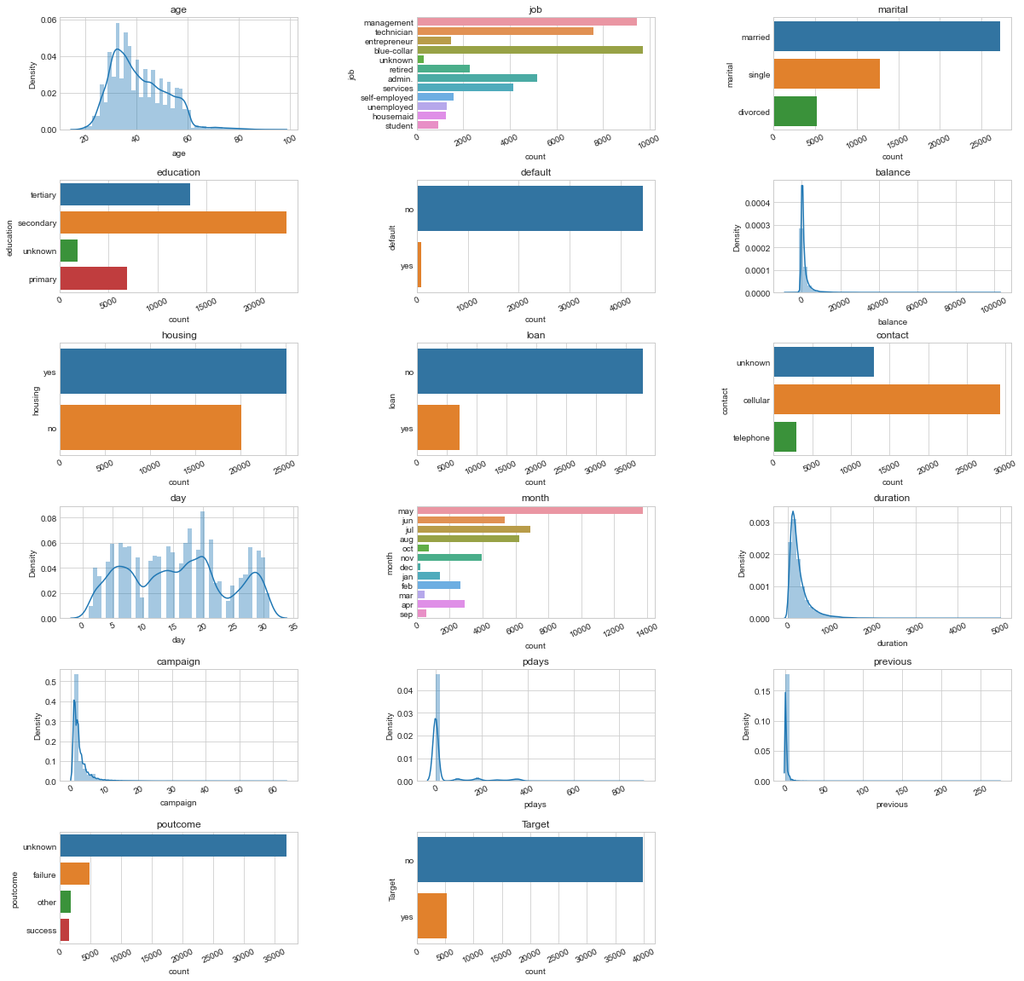

```python
# Let’s plot the distribution of each feature
def plot_distribution(dataset, cols=5, width=20, height=15, hspace=0.2, wspace=0.5):
    plt.style.use('seaborn-whitegrid')
    fig = plt.figure(figsize=(width,height))
    fig.subplots_adjust(left=None, bottom=None, right=None, top=None, wspace=wspace, hspace=hspace)
    rows = math.ceil(float(dataset.shape[1]) / cols)
    for i, column in enumerate(dataset.columns):
        ax = fig.add_subplot(rows, cols, i + 1)
        ax.set_title(column)
        if dataset.dtypes[column] == np.object:
            g = sns.countplot(y=column, data=dataset)
            substrings = [s.get_text()[:18] for s in g.get_yticklabels()]
            g.set(yticklabels=substrings)
            plt.xticks(rotation=25)
        else:
            g = sns.distplot(dataset[column])
            plt.xticks(rotation=25)

plot_distribution(data, cols=3, width=20, height=20, hspace=0.45, wspace=0.5)
```

```python
# To perform our data analysis, let's create new dataframes.
data_bin = pd.DataFrame() # To contain our dataframe with our discretised continuous variables
data_con = pd.DataFrame() # To contain our dataframe with our continuous variables
```

### Feature Target

This is the feature we are trying to predict. We'll change the string to a binary 0/1. 1 for yes and 0 for no

```python
# Let's fix the Target Feature
data.loc[data['Target'] == 'yes', 'Target'] = 1
data.loc[data['Target'] == 'no', 'Target'] = 0

data_bin['Target'] = data['Target']
data_con['Target'] = data['Target']
```

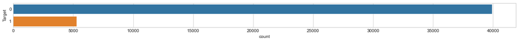

```python
plt.style.use('seaborn-whitegrid')
fig = plt.figure(figsize=(20,1))
sns.countplot(y="Target", data=data_bin)
```

### Feature Age

We will use the Pandas Cut function to bin the data in equally sized buckets. We will also add our original feature to the dataset_con dataframe.

```python
data_bin['age'] = pd.cut(data['age'], 10) # discretised
data_con['age'] = data['age'] # non-discretised
```

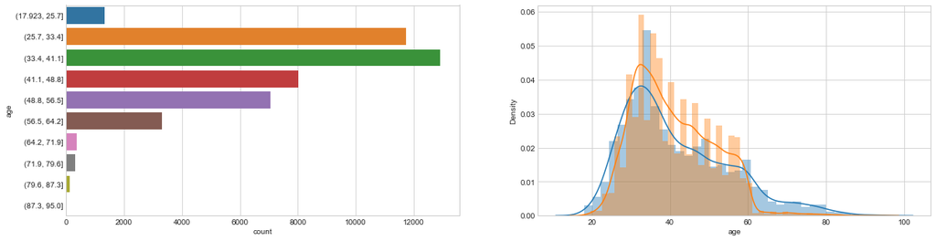

```python
plt.style.use('seaborn-whitegrid')
fig = plt.figure(figsize=(20,5))

plt.subplot(1, 2, 1)
sns.countplot(y="age", data=data_bin)

plt.subplot(1, 2, 2)
sns.distplot(data_con.loc[data_con['Target'] == 1]['age'], kde_kws={"label": "yes"});
sns.distplot(data_con.loc[data_con['Target'] == 0]['age'], kde_kws={"label": "no"});
```

### Feature jobs

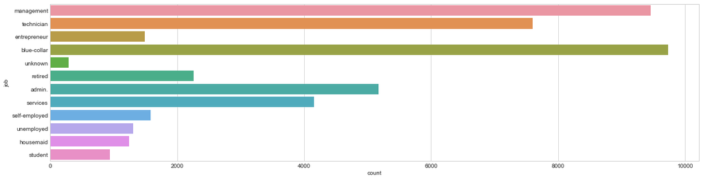

```python
plt.style.use('seaborn-whitegrid')
plt.figure(figsize=(20,5))
sns.countplot(y="job", data=data)
```

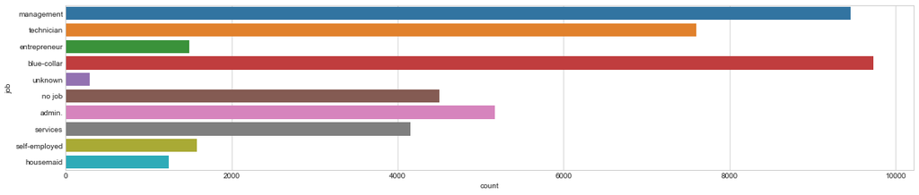

```python
data.loc[data['job'] == 'management'             , 'job'] = 'management'
data.loc[data['job'] == 'technician'             , 'job'] = 'technician'
data.loc[data['job'] == 'entrepreneur'           , 'job'] = 'entrepreneur'
data.loc[data['job'] == 'blue-collar'            , 'job'] = 'blue-collar'
data.loc[data['job'] == 'unknow'                 , 'job'] = 'unknow'
data.loc[data['job'] == 'admin'                  , 'job'] = 'admin'
data.loc[data['job'] == 'services'               , 'job'] = 'services'
data.loc[data['job'] == 'self-employed'          , 'job'] = 'self-employed'
data.loc[data['job'] == 'housemaid'              , 'job'] = 'housemaid'
data.loc[data['job'] == 'retired'                , 'job'] = 'no job'
data.loc[data['job'] == 'unemployed'             , 'job'] = 'no job'
data.loc[data['job'] == 'student'                , 'job'] = 'no job'

data_bin['job'] = data['job']
data_con['job'] = data['job']

plt.style.use('seaborn-whitegrid')
fig = plt.figure(figsize=(20,4))
sns.countplot(y="job", data=data_bin);
```

### Feature Balance

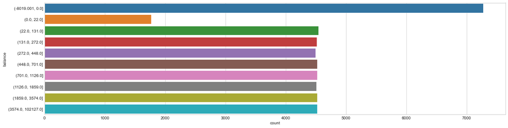

```python
# Let's use the Pandas Cut function to bin the data in equally sized buckets
data_bin['balance'] = pd.qcut(data['balance'], 10)
data_con['balance'] = data['balance']

plt.style.use('seaborn-whitegrid')
fig = plt.figure(figsize=(20,5))
sns.countplot(y="balance", data=data_bin);
```

### Feature: Day

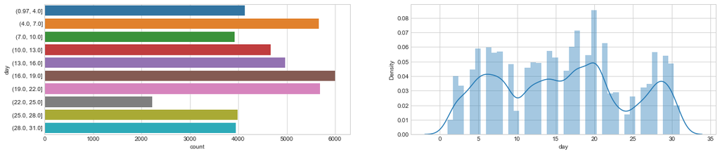

```python
# Let's use the Pandas Cut function to bin the data in equally sized buckets
data_bin['day'] = pd.cut(data['day'], 10)
data_con['day'] = data['day']

plt.style.use('seaborn-whitegrid')
fig = plt.figure(figsize=(20,4))

plt.subplot(1, 2, 1)
sns.countplot(y="day", data=data_bin)

plt.subplot(1, 2, 2)
sns.distplot(data_con['day'])
```

### Feature: Duration

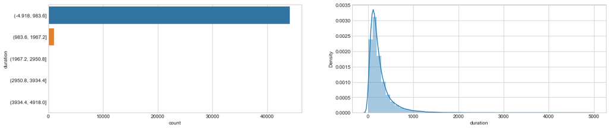

```python
# Let's use the Pandas Cut function to bin the data in equally sized buckets
data_bin['duration'] = pd.cut(data['duration'], 5)
data_con['duration'] = data['duration']

plt.style.use('seaborn-whitegrid')
fig = plt.figure(figsize=(20,4))

plt.subplot(1, 2, 1)
sns.countplot(y="duration", data=data_bin)

plt.subplot(1, 2, 2)
sns.distplot(data_con['duration'])
```

### Feature: Campain

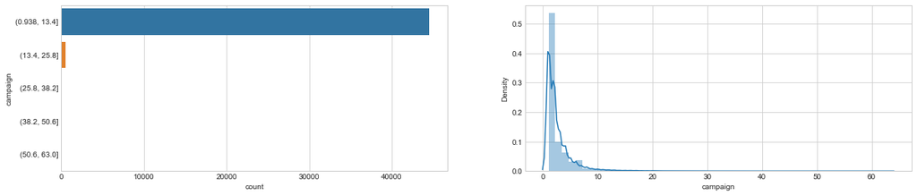

```python
# Let's use the Pandas Cut function to bin the data in equally sized buckets
data_bin['campaign'] = pd.cut(data['campaign'], 5)
data_con['campaign'] = data['campaign']

plt.style.use('seaborn-whitegrid')
fig = plt.figure(figsize=(20,4))

plt.subplot(1, 2, 1)
sns.countplot(y="campaign", data=data_bin)

plt.subplot(1, 2, 2)
sns.distplot(data_con['campaign'])
```

### Feature: pdays

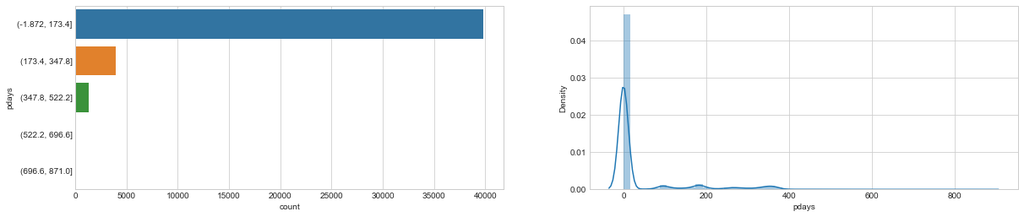

```python
# Let's use the Pandas Cut function to bin the data in equally sized buckets
data_bin['pdays'] = pd.cut(data['pdays'], 5)
data_con['pdays'] = data['pdays']

plt.style.use('seaborn-whitegrid')
fig = plt.figure(figsize=(20,4))

plt.subplot(1, 2, 1)
sns.countplot(y="pdays", data=data_bin)

plt.subplot(1, 2, 2)
sns.distplot(data_con['pdays'])
```

### Feature: previous

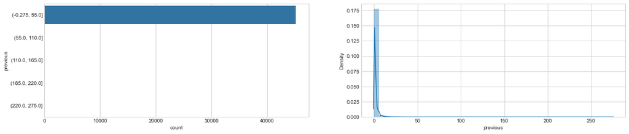

```python
# Let's use the Pandas Cut function to bin the data in equally sized buckets
data_bin['previous'] = pd.cut(data['previous'], 5)
data_con['previous'] = data['previous']

plt.style.use('seaborn-whitegrid')
fig = plt.figure(figsize=(20,4))

plt.subplot(1, 2, 1)
sns.countplot(y="previous", data=data_bin)

plt.subplot(1, 2, 2)
sns.distplot(data_con['previous'])
```

### Feature: marital, education, default, housing, loan, contact, month, poutcome

```python
data_bin['marital'] = data_con['marital'] = data['marital']
data_bin['education'] = data_con['education'] = data['education']
data_bin['default'] = data_con['default'] = data['default']
data_bin['housing'] = data_con['housing'] = data['housing']
data_bin['loan'] = data_con['loan'] = data['loan']
data_bin['contact'] = data_con['contact'] = data['contact']
data_bin['month'] = data_con['month'] = data['month']
data_bin['poutcome'] = data_con['poutcome'] = data['poutcome']
```

### Bi-variate Analysis

So far, we have analised all features individually. Let's now start combining some of these features together to obtain further insight into the interactions between them

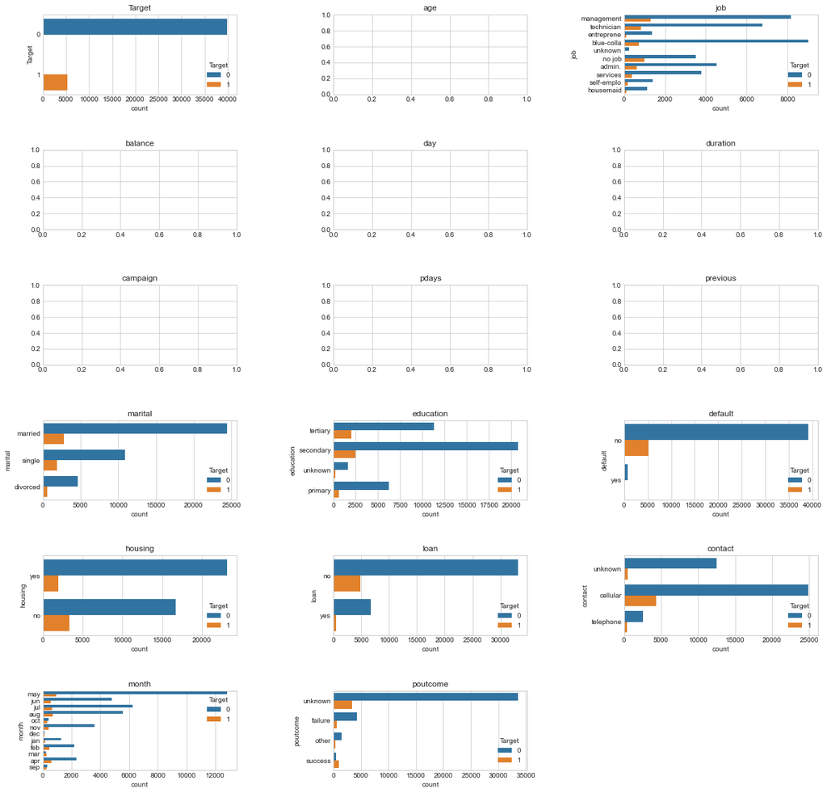

```python
# Plot a count of the categories from each categorical feature split by our prediction class
def plot_bivariate_bar(dataset, hue, cols=5, width=20, height=20, hspace=0.2, wspace=1):
    plt.style.use('seaborn-whitegrid')
    fig = plt.figure(figsize=(width,height))
    fig.subplots_adjust(left=None, bottom=None, right=None, top=None, wspace=wspace, hspace=hspace)
    rows = math.ceil(float(dataset.shape[1]) / cols)

    for i, column in enumerate(dataset.columns):
        ax = fig.add_subplot(rows, cols, i + 1)
        ax.set_title(column)
        if dataset.dtypes[column] == np.object:
            g = sns.countplot(y=column, hue=hue, data=dataset)
            substrings = [s.get_text()[:10] for s in g.get_yticklabels()]
            g.set(yticklabels=substrings)

plot_bivariate_bar(data_con, hue='Target', cols=3, width=20, height=20, hspace=0.7, wspace=0.5)
```

# Feature Encoding

```python
# One Hot Encodes all labels before Machine Learning
one_hot_cols = data_bin.columns.tolist()
one_hot_cols.remove('Target')
data_bin_enc = pd.get_dummies(data_bin, columns=one_hot_cols)

data_bin_enc.head()
```

|  | Target | age_(17.923, 25.7] | age_(25.7, 33.4] | age_(33.4, 41.1] | age_(41.1, 48.8] | age_(48.8, 56.5] | age_(56.5, 64.2] | age_(64.2, 71.9] | age_(71.9, 79.6] | age_(79.6, 87.3] | ... | month_jun | month_mar | month_may | month_nov | month_oct | month_sep | poutcome_failure | poutcome_other | poutcome_success | poutcome_unknown |
| --- | --- | --- | --- | --- | --- | --- | --- | --- | --- | --- | --- | --- | --- | --- | --- | --- | --- | --- | --- | --- | --- |
| 0 | 0 | 0 | 0 | 0 | 0 | 0 | 1 | 0 | 0 | 0 | ... | 0 | 0 | 1 | 0 | 0 | 0 | 0 | 0 | 0 | 1 |
| 1 | 0 | 0 | 0 | 0 | 1 | 0 | 0 | 0 | 0 | 0 | ... | 0 | 0 | 1 | 0 | 0 | 0 | 0 | 0 | 0 | 1 |
| 2 | 0 | 0 | 1 | 0 | 0 | 0 | 0 | 0 | 0 | 0 | ... | 0 | 0 | 1 | 0 | 0 | 0 | 0 | 0 | 0 | 1 |
| 3 | 0 | 0 | 0 | 0 | 1 | 0 | 0 | 0 | 0 | 0 | ... | 0 | 0 | 1 | 0 | 0 | 0 | 0 | 0 | 0 | 1 |
| 4 | 0 | 0 | 1 | 0 | 0 | 0 | 0 | 0 | 0 | 0 | ... | 0 | 0 | 1 | 0 | 0 | 0 | 0 | 0 | 0 | 1 |

5 rows × 93 columns

```python
# Label Encode all labels
data_con_enc = data_con.apply(LabelEncoder().fit_transform)

data_con_enc.head()
```

|  | Target | age | job | balance | day | duration | campaign | pdays | previous | marital | education | default | housing | loan | contact | month | poutcome |
| --- | --- | --- | --- | --- | --- | --- | --- | --- | --- | --- | --- | --- | --- | --- | --- | --- | --- |
| 0 | 0 | 40 | 4 | 3036 | 4 | 261 | 0 | 0 | 0 | 1 | 2 | 0 | 1 | 0 | 2 | 8 | 3 |
| 1 | 0 | 26 | 8 | 945 | 4 | 151 | 0 | 0 | 0 | 2 | 1 | 0 | 1 | 0 | 2 | 8 | 3 |
| 2 | 0 | 15 | 2 | 918 | 4 | 76 | 0 | 0 | 0 | 1 | 1 | 0 | 1 | 1 | 2 | 8 | 3 |
| 3 | 0 | 29 | 1 | 2420 | 4 | 92 | 0 | 0 | 0 | 1 | 3 | 0 | 1 | 0 | 2 | 8 | 3 |
| 4 | 0 | 15 | 9 | 917 | 4 | 198 | 0 | 0 | 0 | 2 | 3 | 0 | 0 | 0 | 2 | 8 | 3 |

## Feature Correlation

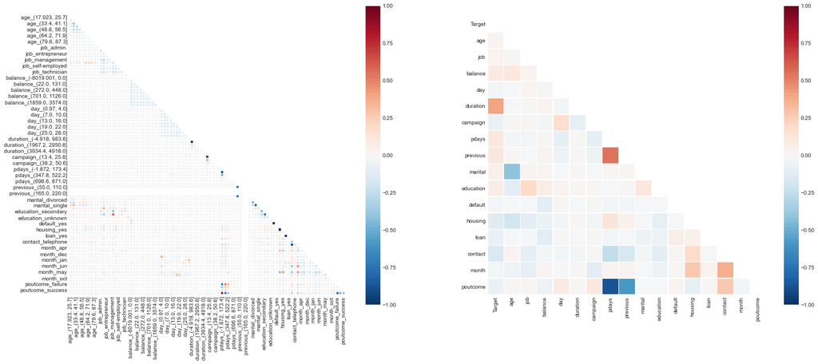

```python
# Create a correlation plot of both datasets.
plt.style.use('seaborn-whitegrid')
fig = plt.figure(figsize=(25,10))
plt.subplot(1, 2, 1)

# Generate a mask for the upper triangle
mask = np.zeros_like(data_bin_enc.corr(), dtype=np.bool)
mask[np.triu_indices_from(mask)] = True
sns.heatmap(data_bin_enc.corr(),
            vmin=-1, vmax=1,
            square=True,
            cmap=sns.color_palette("RdBu_r", 100),
            mask=mask,
            linewidths=.5);

plt.subplot(1, 2, 2)
mask = np.zeros_like(data_con_enc.corr(), dtype=np.bool)
mask[np.triu_indices_from(mask)] = True
sns.heatmap(data_con_enc.corr(),
            vmin=-1, vmax=1,
            square=True,
            cmap=sns.color_palette("RdBu_r", 100),
            mask=mask,
            linewidths=.5);
```

Feature duration highly affects the output target

## Feature Important

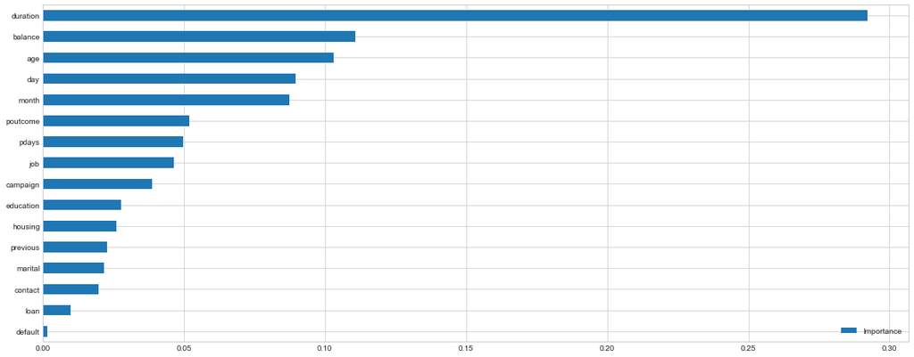

```python
# Using Random Forest to gain an insight on Feature Importance
clf = RandomForestClassifier()
clf.fit(data_con_enc.drop('Target', axis=1), data_con_enc['Target'])

plt.style.use('seaborn-whitegrid')

importance = clf.feature_importances_
importance = pd.DataFrame(importance, index=data_con_enc.drop('Target', axis=1).columns, columns=["Importance"])
importance.sort_values(by='Importance', ascending=True).plot(kind='barh', figsize=(20,len(importance)/2));
```

## PCA

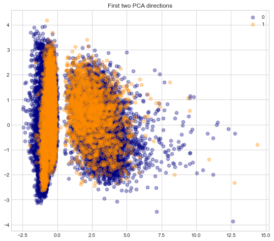

```python
# Apply Scaling
std_scale = preprocessing.StandardScaler().fit(data_con_enc.drop('Target', axis=1))
X = std_scale.transform(data_con_enc.drop('Target', axis=1))
y = data_con_enc['Target']

# Formatting
target_names = [0,1]
colors = ['navy','darkorange']
lw = 2
alpha = 0.3

# Components PCA
plt.style.use('seaborn-whitegrid')
plt.figure(2, figsize=(20, 8))

plt.subplot(1, 2, 1)
pca = PCA(n_components=2)
X_r = pca.fit(X).transform(X)
for color, i, target_name in zip(colors, [0, 1], target_names):
    plt.scatter(X_r[y == i, 0], X_r[y == i, 1],
                color=color,
                alpha=alpha,
                lw=lw,
                label=target_name)
plt.legend(loc='best', shadow=False, scatterpoints=1)
plt.title('First two PCA directions')
```

## Selecting Dataset

```python
selected_dataset = data_con_enc
selected_dataset.head()
```

|  | Target | age | job | balance | day | duration | campaign | pdays | previous | marital | education | default | housing | loan | contact | month | poutcome |
| --- | --- | --- | --- | --- | --- | --- | --- | --- | --- | --- | --- | --- | --- | --- | --- | --- | --- |
| 0 | 0 | 40 | 4 | 3036 | 4 | 261 | 0 | 0 | 0 | 1 | 2 | 0 | 1 | 0 | 2 | 8 | 3 |
| 1 | 0 | 26 | 8 | 945 | 4 | 151 | 0 | 0 | 0 | 2 | 1 | 0 | 1 | 0 | 2 | 8 | 3 |
| 2 | 0 | 15 | 2 | 918 | 4 | 76 | 0 | 0 | 0 | 1 | 1 | 0 | 1 | 1 | 2 | 8 | 3 |
| 3 | 0 | 29 | 1 | 2420 | 4 | 92 | 0 | 0 | 0 | 1 | 3 | 0 | 1 | 0 | 2 | 8 | 3 |
| 4 | 0 | 15 | 9 | 917 | 4 | 198 | 0 | 0 | 0 | 2 | 3 | 0 | 0 | 0 | 2 | 8 | 3 |

## Splitting Data into Training and Testing Datasets

```python
from sklearn.model_selection import train_test_split
y = selected_dataset["Target"]
X = selected_dataset.drop(["Target"], axis = 1)
X_train, X_test, y_train, y_test = train_test_split(X,y,test_size=0.2,random_state=27)
```

```python
# Setting a random seed will guarantee we get the same results
# every time we run our training and testing.
import random
random.seed(1)
```

## Algorithms

From here, we will be running the following algorithms.

KNN

- Logistic Regression
- Random Forest
- Naive Bayes
- Stochastic Gradient Decent
- Linear SVC
- Decision Tree
- Gradient Boosted Trees

Because there's a great deal of repetitiveness on the code for each, we'll create a custom function to analyse this.

For some algorithms, we have also chosen to run a Random Hyperparameter search, to select the best hyperparameters for a given algorithm.

```python
# calculate the fpr and tpr for all thresholds of the classification
def plot_roc_curve(y_test, preds):
    fpr, tpr, threshold = metrics.roc_curve(y_test, preds)
    roc_auc = metrics.auc(fpr, tpr)
    plt.title('Receiver Operating Characteristic')
    plt.plot(fpr, tpr, 'b', label = 'AUC = %0.2f' % roc_auc)
    plt.legend(loc = 'lower right')
    plt.plot([0, 1], [0, 1],'r--')
    plt.xlim([-0.01, 1.01])
    plt.ylim([-0.01, 1.01])
    plt.ylabel('True Positive Rate')
    plt.xlabel('False Positive Rate')
    plt.show()
```

```python
# Function that runs the requested algorithm and returns the accuracy metrics
def fit_ml_algo(algo, X_train, y_train, X_test, cv):
    # One Pass
    model = algo.fit(X_train, y_train)
    test_pred = model.predict(X_test)
    if (isinstance(algo, (LogisticRegression,
                          KNeighborsClassifier,
                          GaussianNB,
                          DecisionTreeClassifier,
                          RandomForestClassifier,
                          GradientBoostingClassifier))):
        probs = model.predict_proba(X_test)[:,1]
    else:
        probs = "Not Available"
    acc = round(model.score(X_test, y_test) * 100, 2)
    # CV
    train_pred = model_selection.cross_val_predict(algo,
                                                  X_train,
                                                  y_train,
                                                  cv=cv,
                                                  n_jobs = -1)
    acc_cv = round(metrics.accuracy_score(y_train, train_pred) * 100, 2)
    return train_pred, test_pred, acc, acc_cv, probs
```

```python
# Utility function to report best scores
import time
import datetime
def report(results, n_top=5):
    for i in range(1, n_top + 1):
        candidates = np.flatnonzero(results['rank_test_score'] == i)
        for candidate in candidates:
            print("Model with rank: {0}".format(i))
            print("Mean validation score: {0:.3f} (std: {1:.3f})".format(
                  results['mean_test_score'][candidate],
                  results['std_test_score'][candidate]))
            print("Parameters: {0}".format(results['params'][candidate]))
            print("")

# Specify parameters and distributions to sample from
param_dist = {'penalty': ['l2', 'l1'],
                         'class_weight': [None, 'balanced'],
                         'C': np.logspace(-20, 20, 10000),
                         'intercept_scaling': np.logspace(-20, 20, 10000)}

# Run Randomized Search
n_iter_search = 10
lrc = LogisticRegression()
random_search = RandomizedSearchCV(lrc,
                                   n_jobs=-1,
                                   param_distributions=param_dist,
                                   n_iter=n_iter_search)

start = time.time()
random_search.fit(X_train, y_train)
print("RandomizedSearchCV took %.2f seconds for %d candidates"
      " parameter settings." % ((time.time() - start), n_iter_search))
report(random_search.cv_results_)
```

```
RandomizedSearchCV took 4.00 seconds for 10 candidates parameter settings.
Model with rank: 1
Mean validation score: 0.886 (std: 0.001)
Parameters: {'penalty': 'l2', 'intercept_scaling': 1.2164899093339455e-09, 'class_weight': None, 'C': 8603862.660878913}

Model with rank: 2
Mean validation score: 0.886 (std: 0.001)
Parameters: {'penalty': 'l2', 'intercept_scaling': 1509794683.671856, 'class_weight': None, 'C': 9.421008806068587}

Model with rank: 3
Mean validation score: 0.882 (std: 0.000)
Parameters: {'penalty': 'l2', 'intercept_scaling': 1.1937343494296951e-11, 'class_weight': None, 'C': 8.8083485080715e-12}

Model with rank: 4
Mean validation score: 0.788 (std: 0.003)
Parameters: {'penalty': 'l2', 'intercept_scaling': 245945615.02449164, 'class_weight': 'balanced', 'C': 1.50424207380589e-07}

Model with rank: 5
Mean validation score: 0.777 (std: 0.007)
Parameters: {'penalty': 'l2', 'intercept_scaling': 9.940305683076937e-07, 'class_weight': 'balanced', 'C': 19378882651844.51}
```

```python
# Logistic Regression
start_time = time.time()
train_pred_log, test_pred_log, acc_log, acc_cv_log, probs_log = fit_ml_algo(LogisticRegression(n_jobs = -1),
                                                                 X_train,
                                                                 y_train,
                                                                 X_test,
                                                                 10)
log_time = (time.time() - start_time)
print("Accuracy: %s" % acc_log)
print("Accuracy CV 10-Fold: %s" % acc_cv_log)
print("Running Time: %s" % datetime.timedelta(seconds=log_time))
```

```
Accuracy: 88.82
Accuracy CV 10-Fold: 88.57
Running Time: 0:00:04.284442
```

```python
print(metrics.classification_report(y_train, train_pred_log))
```

```
              precision    recall  f1-score   support

           0       0.90      0.98      0.94     31898
           1       0.54      0.20      0.29      4270

    accuracy                           0.89     36168
   macro avg       0.72      0.59      0.61     36168
weighted avg       0.86      0.89      0.86     36168
```

```python
print(metrics.classification_report(y_test, test_pred_log))
```

```
              precision    recall  f1-score   support

           0       0.91      0.98      0.94      8024
           1       0.51      0.20      0.28      1019

    accuracy                           0.89      9043
   macro avg       0.71      0.59      0.61      9043
weighted avg       0.86      0.89      0.87      9043
```

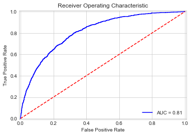

```python
plot_roc_curve(y_test, probs_log)
```

```python
# k-Nearest Neighbors
start_time = time.time()
train_pred_knn, test_pred_knn, acc_knn, acc_cv_knn, probs_knn = fit_ml_algo(KNeighborsClassifier(n_neighbors = 3,
                                                                                                 n_jobs = -1),
                                                                                                 X_train,
                                                                                                 y_train,
                                                                                                 X_test,
                                                                                                 10)
knn_time = (time.time() - start_time)
print("Accuracy: %s" % acc_knn)
print("Accuracy CV 10-Fold: %s" % acc_cv_knn)
print("Running Time: %s" % datetime.timedelta(seconds=knn_time))
```

```
Accuracy: 88.17
Accuracy CV 10-Fold: 87.56
Running Time: 0:03:33.350845
```

```python
print(metrics.classification_report(y_train, train_pred_knn))
```

```
              precision    recall  f1-score   support

           0       0.91      0.95      0.93     31898
           1       0.46      0.30      0.36      4270

    accuracy                           0.88     36168
   macro avg       0.68      0.62      0.65     36168
weighted avg       0.86      0.88      0.86     36168
```

```python
print(metrics.classification_report(y_test, test_pred_knn))
```

```
              precision    recall  f1-score   support

           0       0.92      0.95      0.93      8024
           1       0.46      0.31      0.37      1019

    accuracy                           0.88      9043
   macro avg       0.69      0.63      0.65      9043
weighted avg       0.86      0.88      0.87      9043
```

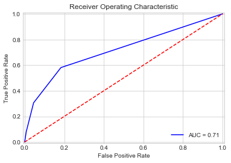

```python
plot_roc_curve(y_test, probs_knn)
```

```python
# Gaussian Naive Bayes
start_time = time.time()
train_pred_gaussian, test_pred_gaussian, acc_gaussian, acc_cv_gaussian, probs_gau = fit_ml_algo(GaussianNB(),
                                                                                     X_train,
                                                                                     y_train,
                                                                                     X_test,
                                                                                     10)
gaussian_time = (time.time() - start_time)
print("Accuracy: %s" % acc_gaussian)
print("Accuracy CV 10-Fold: %s" % acc_cv_gaussian)
print("Running Time: %s" % datetime.timedelta(seconds=gaussian_time))
```

```
Accuracy: 83.69
Accuracy CV 10-Fold: 83.69
Running Time: 0:00:00.475197
```

```python
print(metrics.classification_report(y_train, train_pred_gaussian))
```

```
              precision    recall  f1-score   support

           0       0.93      0.88      0.90     31898
           1       0.37      0.52      0.43      4270

    accuracy                           0.84     36168
   macro avg       0.65      0.70      0.67     36168
weighted avg       0.86      0.84      0.85     36168
```

```python
print(metrics.classification_report(y_test, test_pred_gaussian))
```

```
              precision    recall  f1-score   support

           0       0.93      0.88      0.91      8024
           1       0.35      0.51      0.41      1019

    accuracy                           0.84      9043
   macro avg       0.64      0.69      0.66      9043
weighted avg       0.87      0.84      0.85      9043
```

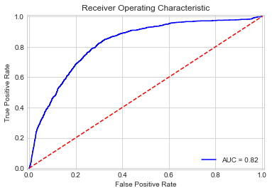

```python
plot_roc_curve(y_test, probs_gau)
```

```python
# Linear SVC
start_time = time.time()
train_pred_svc, test_pred_svc, acc_linear_svc, acc_cv_linear_svc, _ = fit_ml_algo(LinearSVC(),
                                                                                           X_train,
                                                                                           y_train,
                                                                                           X_test,
                                                                                           10)
linear_svc_time = (time.time() - start_time)
print("Accuracy: %s" % acc_linear_svc)
print("Accuracy CV 10-Fold: %s" % acc_cv_linear_svc)
print("Running Time: %s" % datetime.timedelta(seconds=linear_svc_time))
```

```
Accuracy: 88.81
Accuracy CV 10-Fold: 87.24
Running Time: 0:00:48.745946
```

```python
print(metrics.classification_report(y_train, train_pred_svc))
```

```
              precision    recall  f1-score   support

           0       0.89      0.97      0.93     31898
           1       0.37      0.12      0.18      4270

    accuracy                           0.87     36168
   macro avg       0.63      0.54      0.55     36168
weighted avg       0.83      0.87      0.84     36168
```

```python
print(metrics.classification_report(y_test, test_pred_svc))
```

```
              precision    recall  f1-score   support

           0       0.89      1.00      0.94      8024
           1       0.67      0.01      0.03      1019

    accuracy                           0.89      9043
   macro avg       0.78      0.51      0.48      9043
weighted avg       0.86      0.89      0.84      9043
```

```python
# Stochastic Gradient Descent
start_time = time.time()
train_pred_sgd, test_pred_sgd, acc_sgd, acc_cv_sgd, _ = fit_ml_algo(SGDClassifier(n_jobs = -1),
                                                                 X_train,
                                                                 y_train,
                                                                 X_test,
                                                                 10)
sgd_time = (time.time() - start_time)
print("Accuracy: %s" % acc_sgd)
print("Accuracy CV 10-Fold: %s" % acc_cv_sgd)
print("Running Time: %s" % datetime.timedelta(seconds=sgd_time))
```

```
Accuracy: 82.12
Accuracy CV 10-Fold: 86.71
Running Time: 0:00:05.327132
```

```python
print(metrics.classification_report(y_train, train_pred_sgd))
```

```
              precision    recall  f1-score   support

           0       0.90      0.96      0.93     31898
           1       0.36      0.16      0.22      4270

    accuracy                           0.87     36168
   macro avg       0.63      0.56      0.58     36168
weighted avg       0.83      0.87      0.84     36168
```

```python
print(metrics.classification_report(y_test, test_pred_sgd))
```

```
              precision    recall  f1-score   support

           0       0.94      0.85      0.89      8024
           1       0.34      0.60      0.43      1019

    accuracy                           0.82      9043
   macro avg       0.64      0.72      0.66      9043
weighted avg       0.87      0.82      0.84      9043
```

```python
# Decision Tree Classifier
start_time = time.time()
train_pred_dt, test_pred_dt, acc_dt, acc_cv_dt, probs_dt = fit_ml_algo(DecisionTreeClassifier(),
                                                             X_train,
                                                             y_train,
                                                             X_test,
                                                             10)
dt_time = (time.time() - start_time)
print("Accuracy: %s" % acc_dt)
print("Accuracy CV 10-Fold: %s" % acc_cv_dt)
print("Running Time: %s" % datetime.timedelta(seconds=dt_time))
```

```
Accuracy: 87.68
Accuracy CV 10-Fold: 87.37
Running Time: 0:00:01.779711
```

```python
print(metrics.classification_report(y_train, train_pred_dt))
```

```
              precision    recall  f1-score   support

           0       0.93      0.93      0.93     31898
           1       0.47      0.48      0.48      4270

    accuracy                           0.87     36168
   macro avg       0.70      0.71      0.70     36168
weighted avg       0.88      0.87      0.87     36168
```

```python
print(metrics.classification_report(y_test, test_pred_dt))
```

```
              precision    recall  f1-score   support

           0       0.93      0.93      0.93      8024
           1       0.46      0.47      0.46      1019

    accuracy                           0.88      9043
   macro avg       0.69      0.70      0.70      9043
weighted avg       0.88      0.88      0.88      9043
```

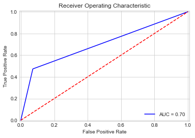

```python
plot_roc_curve(y_test, probs_dt)
```

```python
# Random Forest Classifier - Random Search for Hyperparameters

# Utility function to report best scores
def report(results, n_top=5):
    for i in range(1, n_top + 1):
        candidates = np.flatnonzero(results['rank_test_score'] == i)
        for candidate in candidates:
            print("Model with rank: {0}".format(i))
            print("Mean validation score: {0:.3f} (std: {1:.3f})".format(
                  results['mean_test_score'][candidate],
                  results['std_test_score'][candidate]))
            print("Parameters: {0}".format(results['params'][candidate]))
            print("")

# Specify parameters and distributions to sample from
param_dist = {"max_depth": [10, None],
              "max_features": sp_randint(1, 11),
              "min_samples_split": sp_randint(2, 20),
              "min_samples_leaf": sp_randint(1, 11),
              "bootstrap": [True, False],
              "criterion": ["gini", "entropy"]}

# Run Randomized Search
n_iter_search = 10
rfc = RandomForestClassifier(n_estimators=10)
random_search = RandomizedSearchCV(rfc,
                                   n_jobs = -1,
                                   param_distributions=param_dist,
                                   n_iter=n_iter_search)

start = time.time()
random_search.fit(X_train, y_train)
print("RandomizedSearchCV took %.2f seconds for %d candidates"
      " parameter settings." % ((time.time() - start), n_iter_search))
report(random_search.cv_results_)
```

```
RandomizedSearchCV took 8.22 seconds for 10 candidates parameter settings.
Model with rank: 1
Mean validation score: 0.902 (std: 0.002)
Parameters: {'bootstrap': False, 'criterion': 'entropy', 'max_depth': 10, 'max_features': 10, 'min_samples_leaf': 4, 'min_samples_split': 3}

Model with rank: 2
Mean validation score: 0.902 (std: 0.001)
Parameters: {'bootstrap': True, 'criterion': 'entropy', 'max_depth': 10, 'max_features': 9, 'min_samples_leaf': 7, 'min_samples_split': 2}

Model with rank: 3
Mean validation score: 0.902 (std: 0.001)
Parameters: {'bootstrap': True, 'criterion': 'entropy', 'max_depth': 10, 'max_features': 9, 'min_samples_leaf': 4, 'min_samples_split': 4}

Model with rank: 4
Mean validation score: 0.902 (std: 0.002)
Parameters: {'bootstrap': True, 'criterion': 'gini', 'max_depth': None, 'max_features': 6, 'min_samples_leaf': 9, 'min_samples_split': 8}

Model with rank: 5
Mean validation score: 0.901 (std: 0.002)
Parameters: {'bootstrap': False, 'criterion': 'gini', 'max_depth': None, 'max_features': 4, 'min_samples_leaf': 3, 'min_samples_split': 11}
```

```python
# Random Forest Classifier
start_time = time.time()
rfc = RandomForestClassifier(n_estimators=10,
                             min_samples_leaf=2,
                             min_samples_split=17,
                             criterion='gini',
                             max_features=8)
train_pred_rf, test_pred_rf, acc_rf, acc_cv_rf, probs_rf = fit_ml_algo(rfc,
                                                             X_train,
                                                             y_train,
                                                             X_test,
                                                             10)
rf_time = (time.time() - start_time)
print("Accuracy: %s" % acc_rf)
print("Accuracy CV 10-Fold: %s" % acc_cv_rf)
print("Running Time: %s" % datetime.timedelta(seconds=rf_time))
```

```
Accuracy: 90.62
Accuracy CV 10-Fold: 90.3
Running Time: 0:00:03.712681
```

```python
print(metrics.classification_report(y_train, train_pred_rf) )
```

```
              precision    recall  f1-score   support

           0       0.93      0.96      0.95     31898
           1       0.62      0.46      0.53      4270

    accuracy                           0.90     36168
   macro avg       0.77      0.71      0.74     36168
weighted avg       0.89      0.90      0.90     36168
```

```python
print(metrics.classification_report(y_test, test_pred_rf))
```

```
              precision    recall  f1-score   support

           0       0.93      0.96      0.95      8024
           1       0.62      0.45      0.52      1019

    accuracy                           0.91      9043
   macro avg       0.77      0.71      0.73      9043
weighted avg       0.90      0.91      0.90      9043
```

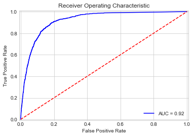

```python
plot_roc_curve(y_test, probs_rf)
```

```python
# Gradient Boosting Trees
start_time = time.time()
train_pred_gbt, test_pred_gbt, acc_gbt, acc_cv_gbt, probs_gbt = fit_ml_algo(GradientBoostingClassifier(),
                                                                 X_train,
                                                                 y_train,
                                                                 X_test,
                                                                 10)
gbt_time = (time.time() - start_time)
print("Accuracy: %s" % acc_gbt)
print("Accuracy CV 10-Fold: %s" % acc_cv_gbt)
print("Running Time: %s" % datetime.timedelta(seconds=gbt_time))
```

```
Accuracy: 90.41
Accuracy CV 10-Fold: 90.39
Running Time: 0:00:24.208397
```

```python
print(metrics.classification_report(y_train, train_pred_gbt))
```

```
              precision    recall  f1-score   support

           0       0.92      0.97      0.95     31898
           1       0.65      0.41      0.50      4270

    accuracy                           0.90     36168
   macro avg       0.79      0.69      0.72     36168
weighted avg       0.89      0.90      0.89     36168
```

```python
print(metrics.classification_report(y_test, test_pred_gbt))
```

```
              precision    recall  f1-score   support

           0       0.93      0.97      0.95      8024
           1       0.62      0.38      0.47      1019

    accuracy                           0.90      9043
   macro avg       0.77      0.68      0.71      9043
weighted avg       0.89      0.90      0.89      9043
```

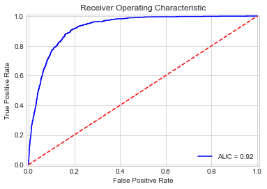

```python
plot_roc_curve(y_test, probs_gbt)
```

## Ranking Results

```python
models = pd.DataFrame({
    'Model': ['KNN', 'Logistic Regression',
              'Random Forest', 'Naive Bayes',
              'Stochastic Gradient Decent', 'Linear SVC',
              'Decision Tree', 'Gradient Boosting Trees'],
    'Score': [
        acc_knn,
        acc_log,
        acc_rf,
        acc_gaussian,
        acc_sgd,
        acc_linear_svc,
        acc_dt,
        acc_gbt
    ]})
models.sort_values(by='Score', ascending=False)
```

|  | Model | Score |
| --- | --- | --- |
| 2 | Random Forest | 90.62 |
| 7 | Gradient Boosting Trees | 90.41 |
| 1 | Logistic Regression | 88.82 |
| 5 | Linear SVC | 88.81 |
| 0 | KNN | 88.17 |
| 6 | Decision Tree | 87.68 |
| 3 | Naive Bayes | 83.69 |
| 4 | Stochastic Gradient Decent | 82.12 |

```python
models = pd.DataFrame({
    'Model': ['KNN', 'Logistic Regression',
              'Random Forest', 'Naive Bayes',
              'Stochastic Gradient Decent', 'Linear SVC',
              'Decision Tree', 'Gradient Boosting Trees'],
    'Score': [
        acc_cv_knn,
        acc_cv_log,
        acc_cv_rf,
        acc_cv_gaussian,
        acc_cv_sgd,
        acc_cv_linear_svc,
        acc_cv_dt,
        acc_cv_gbt
    ]})
models.sort_values(by='Score', ascending=False)
```

|  | Model | Score |
| --- | --- | --- |
| 7 | Gradient Boosting Trees | 90.39 |
| 2 | Random Forest | 90.30 |
| 1 | Logistic Regression | 88.57 |
| 0 | KNN | 87.56 |
| 6 | Decision Tree | 87.37 |
| 5 | Linear SVC | 87.24 |
| 4 | Stochastic Gradient Decent | 86.71 |
| 3 | Naive Bayes | 83.69 |

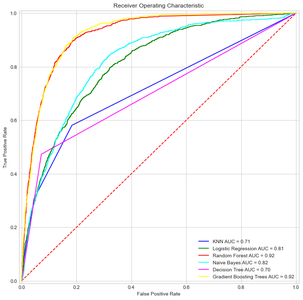

```python
plt.style.use('seaborn-whitegrid')
fig = plt.figure(figsize=(10,10))

models = [
    'KNN',
    'Logistic Regression',
    'Random Forest',
    'Naive Bayes',
    'Decision Tree',
    'Gradient Boosting Trees'
]
probs = [
    probs_knn,
    probs_log,
    probs_rf,
    probs_gau,
    probs_dt,
    probs_gbt
]
colors = [
    'blue',
    'green',
    'red',
    'cyan',
    'magenta',
    'yellow',
]

plt.title('Receiver Operating Characteristic')
plt.plot([0, 1], [0, 1],'r--')
plt.xlim([-0.01, 1.01])
plt.ylim([-0.01, 1.01])
plt.ylabel('True Positive Rate')
plt.xlabel('False Positive Rate')

def plot_roc_curves(y_test, prob, model):
    fpr, tpr, threshold = metrics.roc_curve(y_test, prob)
    roc_auc = metrics.auc(fpr, tpr)
    plt.plot(fpr, tpr, 'b', label = model + ' AUC = %0.2f' % roc_auc, color=colors[i])
    plt.legend(loc = 'lower right')

for i, model in list(enumerate(models)):
    plot_roc_curves(y_test, probs[i], models[i])

plt.show()
```